# Convolutional Neural Networks

## Learned CNN features - weights at layer 3

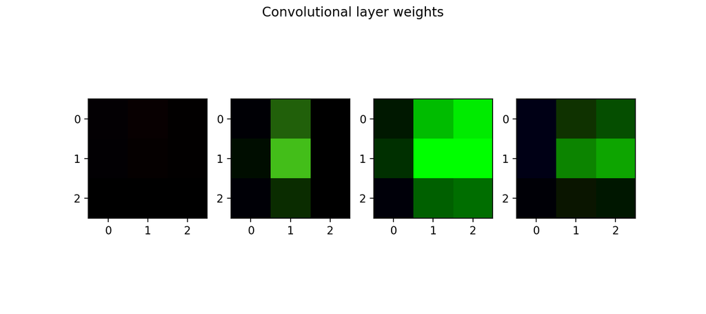

## Learned CNN features - convolution pre-activation at layer 3

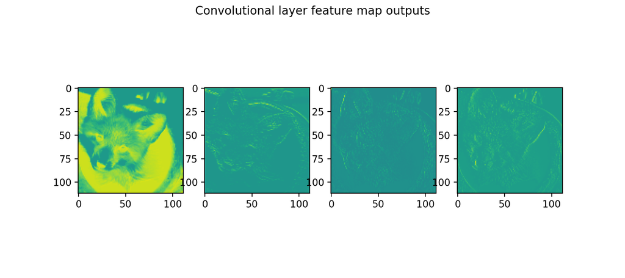

## Learned CNN features - ReLU activations at layer 3

## Learned CNN features - batchnorm at layer 3

## CNN summary

- A convolutional layer is defined by
  - **Kernel:** dimensions, channels (count)
  - **Application rule:** stride, padding
  - **Parameters:** weights, biases
- Convolutions tend to over-focus on texture
  - Using small (3x3) kernels learning from textures easier than learning from large-scale structures
  - Most networks have inductive bias in favour of predicting from texture
  - Many adversarial methods are based on this inductive bias (adding jitter, changing texture)

## Plan for the day

- Introduction
  - Inductive bias
  - Inductive bias in NNs
- Convolutional operator
  - Translation invariance in images
  - Convolutional Neural Networks
- **Advanced convolution variants**
  - **Parameter-free convolution**
  - **Depth-wise separability & shuffle**
  - **Deconvolution & super resolution**
  - **Graph CNNs**

## Parameter-free convolution: pooling

[figure not shown]

- Kernel application
  - As in basic CNNs
  - Stride, kernel dimensions, padding
- Common uses
  - **Input resolution standardization**
  - Non-trainable feature extractor
  - **In-network downsampling**
- Each use is associated with an underlying assumption
- Pooling operator(s):
  - Maximum - **max-pooling**
  - Minimum - min-pooling
  - Average - average-pooling
  - Median - median-pooling
  - other - in principle any function
- Pictured: max pooling

## Maxpooling - code

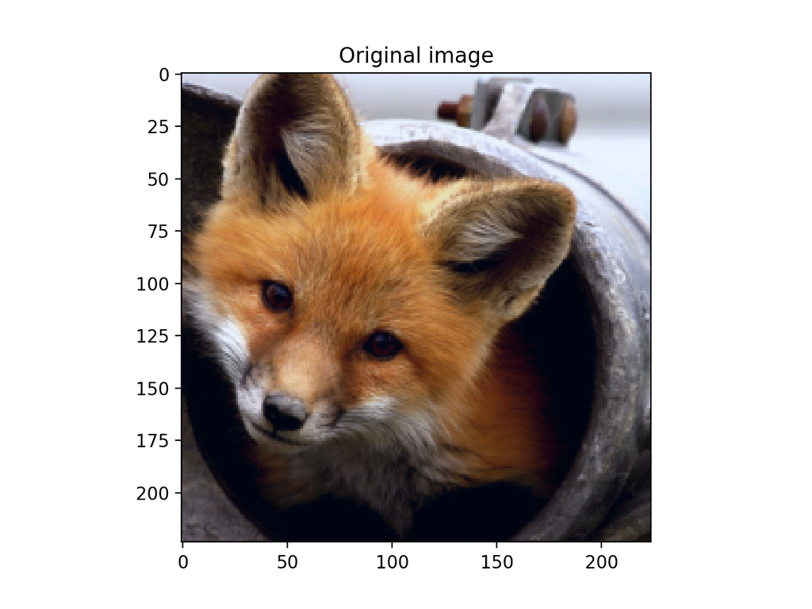

## Maxpooling - code

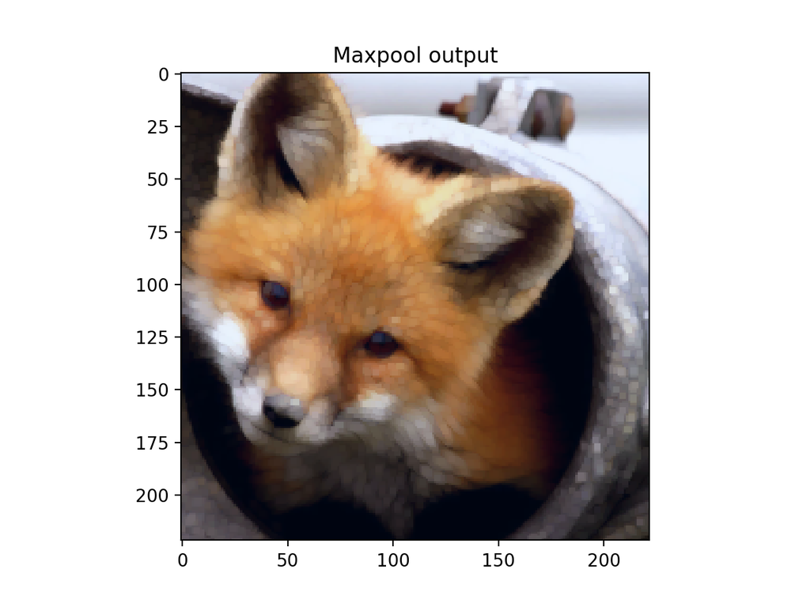

## Revisitting AlexNet

[figure not shown]

## Convolutions vs. fully connected layers

[figure not shown]

- Setup:
  - AlexNet architecture
  - Projection-activation split
  - A single, color image (256×256x3) at inference
  - Execution on Tegra GPU
  - Reported: parameters and latency
- Layer types
  - Feed-forward layers (fully connected)
  - Convolutional layers and pooling layers
  - Other: dropout and softmax
- Convolution benefits:
  - Helps generalization
  - Lowers memory requirements
- No free lunch
  - Weight sharing does not lower MACs
  - Pooling is as costly as a simple convolution
- **Note the total size!**

*Source: Lane et al. (2015) An Early Resource Characterization of DL*

## Depth-wise separability & the MobileNet(s)

Inductive bias: *We assume the optimal kernels of the large model to have layer-wise linearly dependent channels!*

| vanilla convolution | depth-wise separable convolution |
| --- | --- |

Howard et al. (2017)

## Depth-wise separable convolution

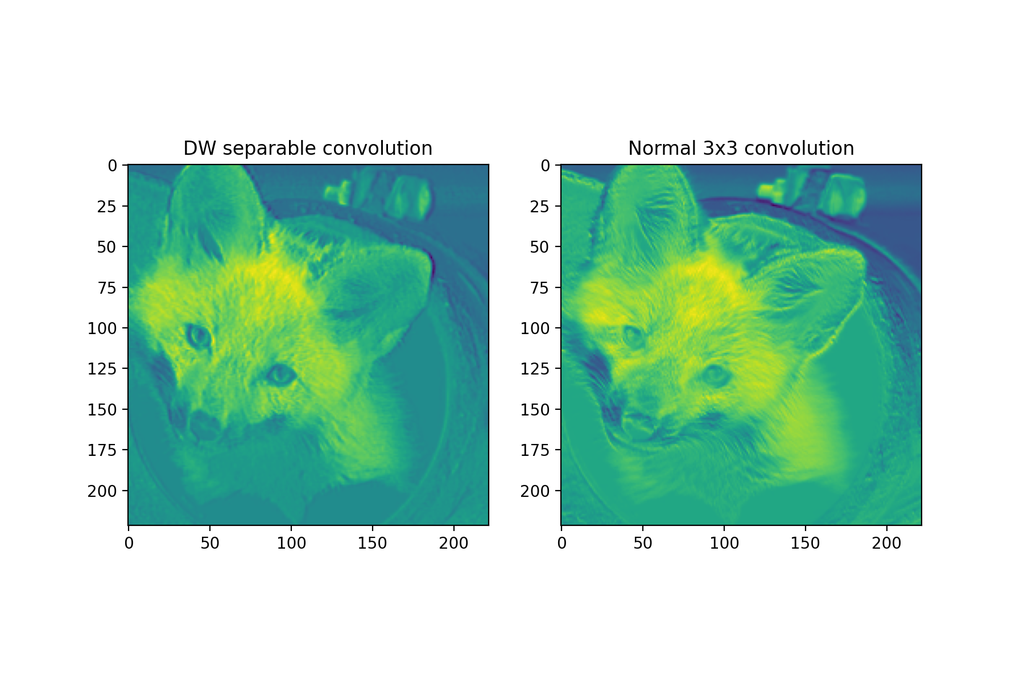

## The MobileNet(s)

| Architecture | Performance |
| --- | --- |

Source:Howard et al. (2017)

## Channel shuffle & the ShuffleNet(s)

[figure not shown]

## Channel shuffle & the ShuffleNet(s)

| Architecture | Performance |
| --- | --- |

Source: Zhang et al. (2017)

## Pixel-shuffle & super resolution

| Low Resolution | High Resolution |
| --- | --- |

[figure not shown]

## Pixel-shuffle

[figure not shown]

Wenzhe Shi, Jose Caballero, **Ferenc Huszar**, Johannes Totz, Andrew P. Aitken, Rob Bishop, Daniel Rueckert, Zehan Wang (2016)

## Super resolution: SRGAN

[figure not shown]

Christian Ledig, Lucas Theis, **Ferenc Huszar**, Jose Caballero, Andrew Cunningham, Alejandro Acosta, Andrew Aitken, Alykhan Tejani, Johannes Totz, Zehan Wang, Wenzhe Shi (2017)

## Super resolution: SRGAN

## Graph convolution - data structure

[figure not shown]

- Graph G is defined by:
  - Vertices V
  - Edges E
  - Adjacency matrix A
- Graph features:
  - Node features $h_i$ and $h_j$
  - Edge features $e_{ij}$
  - Graph features $g$

## Graph convolution - tasks

[figure not shown]

- Graph classification
- Node feature prediction
- Link prediction

Pictured: Fisetin

## Graph convolution

| Spectral GCNNs | Template Matching GCNNs |
| --- | --- |

## Summary of the Day

- Introduction
  - Inductive bias
  - Inductive bias in NNs
- Convolutional operator
  - Translation invariance in images
  - Convolutional Neural Networks
- Advanced convolution variants
  - Parameter-free convolution
  - Depth-wise separability & shuffle
  - Deconvolution & super resolution
  - Graph CNNs

## AlphaFold - the protein folding problem

[figure not shown]

## AlphaFold 1

## AlphaFold 2

[figure not shown]